# Problem set 2: Counting coqui frogs

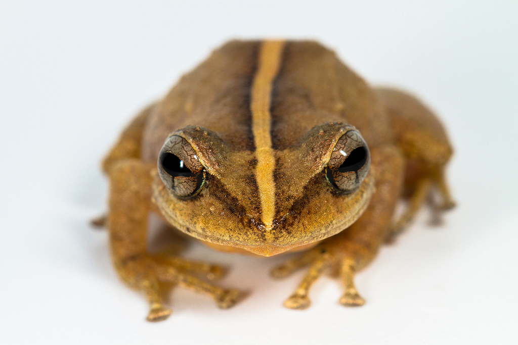

Long-Term Ecological Research (LTER) datasets are incredibly valuable because they provide a wide variety of ecological data for a system. They are also, unfortunately, often incredibly untidy. This week we will explore and tidy a modified version of a coqui frog abundance dataset from the [Luquillo LTER](https://luquillo.lter.network/) in Puerto Rico. Coqui frogs are well known for their mating calls. I highly recommend listening to their calls!

The ten questions draw from every lesson in Module 2. Earlier questions assess individual operations, while later questions combine those operations in complete analyses.

## Grading

**Total points available: 10**

The points allotted for each question are provided in highlighted red bold text (e.g., [1.0]) within the question itself. When applicable, total points for a question may represent the sum of individually graded components, which are provided in red text (e.g., [1.0]).

**Points may be deducted from each question’s original point value:**

- [50% per unapproved function] Use only functions that are listed in “Functions that you may use in this assignment”. Repeated uses of the same unapproved function will not result in additional deductions.
- [50%] Do not include any assignments other than those specified in a question.
- [25%] Do not use numeric column indexing for extracting data from data frames or named lists (e.g., `my_df[[1]]`).
- [10%] Ensure that the class of your response is consistent with the wording of the question (e.g., if you are asked to return a “value” or “vector”, ensure that the resultant object is not a data frame).

*Note: The maximum deduction is the total points value for a given question.*

**An additional 10% of a question’s original point value will be awarded when the response follows all applicable rules in the [Course style guide](https://evansbrians.github.io/gis_2026/resources/course_style_guide/). Style extra credit is assessed separately for each question; a response with one or more style violations receives no style extra credit for that question.**

Click the blue button below to view the functions that you may use in completing this problem set. Make sure that you know what each function does (use `?[function name]` if you do not). Do not use any functions outside of this list!

**Important!** Primitive functions and functions in the *base* package are loaded by default when you start an R session. Functions in *dplyr*, *ggplot2*, *readr*, and *tidyr* are loaded with `library(tidyverse)`. Although the *magrittr* package is not a part of the core tidyverse, the `%>%` function is imported by the *dplyr* (core tidyverse) library.

In answering the questions for this assignment, you may **only** use the following R functions in your submitted R script (but you may use additional functions to explore the data):

- `.Primitive, ()`
- `.Primitive, <-`
- `.Primitive, =`
- `.Primitive, :`
- `.Primitive, !`
- `.Primitive, ==`
- `.Primitive, >`
- `.Primitive, ~`
- `.Primitive, c`
- `base::%in%`
- `base::as.numeric`
- `base::class`
- `base::library`
- `base::mean`
- `base::rm`
- `dplyr::across`
- `dplyr::distinct`
- `dplyr::filter`
- `dplyr::group_by`
- `dplyr::left_join`
- `dplyr::mutate`
- `dplyr::n`
- `dplyr::pull`
- `dplyr::select`
- `dplyr::slice_max`
- `dplyr::summarize`
- `dplyr::ungroup`
- `ggplot2::+`
- `ggplot2::aes`
- `ggplot2::facet_wrap`
- `ggplot2::geom_point`
- `ggplot2::ggplot`
- `ggplot2::labs`
- `ggplot2::scale_color_manual`
- `ggplot2::scale_shape_manual`
- `ggplot2::theme_bw`
- `magrittr::%>%`
- `readr::read_rds`
- `tidyr::pivot_longer`
- `tidyr::pivot_wider`
- `tidyr::separate_wider_delim`

## About the data

This problem set uses `coqui_counts.rds`, an untidy subset of Luquillo LTER transect data that records coqui frog counts by distance along each transect. You can view the [full dataset and metadata in the EDI Data Portal](https://portal.edirepository.org/nis/mapbrowse?packageid=knb-lter-luq.25.1115151).

In this problem set, we will explore the file `coqui_counts.rds`. The data are formatted as a tibble data frame with the following variables:

- `site` (character): The study area where an observation occurred;
- `coordinates` (character): The longitudinal and latitudinal coordinates of the site, in decimal degrees, separated by a comma;
- `transect_id` (numeric, integer): A numeric identifier for the transects that were sampled;
- `habitat_class` (character): A code for the type of habitat where a transect occurred (e.g., G = “gap”, G-E = “gap edge”, F = “forest”, E = “forest edge”);
- `habitat` (character): The type of habitat where the transect occurred;
- `date` (date): The date of a given sampling event;
- `count_0-10m` (numeric, double): The number of coqui frogs observed in the first 10 meters of the transect;
- `count_10-20m` (numeric, double): The number of coqui frogs observed in the second 10 meters of the transect;
- `count_20-30m` (numeric, double): The number of coqui frogs observed in the third 10 meters of the transect;

## Setup

Remember that it is best practice to start with a clean RStudio session (i.e., close any script files, remove names from your global environment, and clear your history).

1. [0.50] Set up your analysis:

- [0.10] Before opening the script, rename `problem_set_2.R` as “problem_set_2_[last name]_[first name].R” using snake case. For example, Tara would name her file `problem_set_2_snedgen_tara.R`.
- [0.15] Open the renamed script in RStudio and attach the tidyverse metapackage to your current R session.
- [0.25] Use a relative file path to read `coqui_counts.rds`, and globally assign the object to the name `coqui`.

*Note: You will submit this script file as your assignment.*

*Hint: You will find the tools for this question in **1.4 Importing, exploring, and exporting data**.*

## Subsetting and extraction

2. [0.50] The same column can be subset as a one-column data frame or extracted as the vector stored inside it. Please:

- [0.20] Pipe `coqui` into a function that subsets the data frame to the `coordinates` column, then pipe that result into `class()`.
- [0.20] Pipe `coqui` into a function that extracts the `coordinates` column, then pipe that result into `class()`.
- [0.10] In a comment, describe how the two operations and their resulting classes differ.

Do not assign either result to a name.

*Hint: You will find the tools for this question in **2.1 Introduction to subsetting and extraction**.*

## Data tidying and mutation

Remember, data exploration should almost always occur in the console pane. You will only be evaluated on the code provided in your submitted script file.

3. [1.25] The columns `coordinates` and `habitat_class` are each a problem of a different kind. A location has separate longitudinal and latitudinal variables, while `habitat_class` redundantly encodes the same attribute as `habitat`. In a single piped statement:

- [0.40] Split `coordinates` into `longitude` and `latitude`.
- [0.35] Convert both new columns to the numeric class in a single function call.
- [0.25] Remove `habitat_class` from the data frame.
- [0.25] Globally assign the result to the name `coqui_no_class`, then remove the name `coqui` from your global environment.

*Note: Changing the class of a column is a data cleaning step rather than a tidying step (see **2.6 Tidy data**).*

*Hint: You will find the tools for this question in **2.4 Reshaping data frames**, **2.6 Tidy data**, and **2.1 Introduction to subsetting and extraction**.*

4. [1.0] Each count observation was made on a given date, at a given distance along a given transect. The three count columns spread the variable `distance_class` across column names and place three count observations in each row. In a single piped statement:

- [0.65] Pivot the count columns into the variables `distance_class` and `count`. Remove the redundant `count_` prefix from the values of `distance_class` as part of the pivot.
- [0.25] Add the logical column `detected`, which indicates whether `count` is greater than zero.
- [0.10] Globally assign the result to `coqui_long`, then remove the name `coqui_no_class` from your global environment.

*Hint: You will find the tools for this question in **2.4 Reshaping data frames** and **2.2 Introduction to mutation**.*

## Grouped operations and summarizing

5. [1.0] In a single piped statement:

- [0.25] Choose a grouping method and group `coqui_long` by `site` and `distance_class`. In a comment, explain why that grouping method is appropriate for the operations below.
- [0.25] Add `mean_count`, the mean count within each group, while retaining every row.
- [0.25] While the grouping remains, subset to count observations that exceed their group mean.
- [0.25] Remove the grouping, then subset the result to `site`, `transect_id`, `date`, `distance_class`, `count`, and `mean_count`.

Do not assign the result to a name.

*Hint: You will find the tools for this question in **2.3 Grouped operations and summarizing**.*

6. [1.0] In a single piped statement:

- [0.60] Choose a grouping method and return the proportion of count observations in which at least one coqui frog was detected and the number of count observations within each combination of `habitat` and `distance_class`. Name the summary columns `detection_rate` and `observations_per_distance`. In a comment, explain why that grouping method is appropriate for this analysis.
- [0.40] Pivot the summary wider so that the values of `distance_class` form column names and `detection_rate` supplies their values. Retain `observations_per_distance` as a column.

Do not assign the result to a name.

*Hint: The mean of a logical vector is the proportion of its values that are `TRUE`.*

*Hint: You will find the tools for this question in **2.3 Grouped operations and summarizing** and **2.4 Reshaping data frames**.*

## Data visualization

As always, we should visualize our data early and often.

7. [1.25] Plot the count observations through time:

- [0.25] Pipe `coqui_long` into `ggplot()`. Map `date` to the x-axis, `count` to the y-axis, `habitat` to color, and `distance_class` to shape.
- [0.15] Add a point geometry.
- [0.25] Set the four habitat colors and three distance-class shapes manually. Choose colors that remain distinguishable for a reader with a color vision deficiency.
- [0.20] Label the x-axis `Date`, the y-axis `Coqui count`, and the plot `Coqui counts through time`. Give both legends informative titles.
- [0.20] Create one facet for each site.
- [0.20] Apply `theme_bw()`.

*Hint: You will find the tools for this question in **2.5 Introduction to data visualization with ggplot2**.*

## Ranked subsetting

8. [0.75] Return the observation with the largest count within each combination of site and distance class:

- [0.50] Use a ranked subsetting function with a per-operation grouping argument. If the largest values are tied, return only one of the tied rows.
- [0.25] Subset the result to `site`, `distance_class`, `transect_id`, `date`, and `count`.

Do not assign the result to a name.

*Hint: You will find the tools for this question in **2.1 Introduction to subsetting and extraction** and **2.3 Grouped operations and summarizing**.*

## Tidy data and relational tables

9. [0.75] Explore the observational levels in `coqui_long`:

- [0.20] Return the distinct combinations of `site`, `longitude`, and `latitude`.
- [0.20] Return the distinct combinations of `transect_id`, `site`, and `habitat`.
- [0.35] In a comment, name the tidy data rule that `coqui_long` violates. Identify the variables that uniquely identify a site, a transect, and a count observation, and explain how the two code blocks support your conclusion.

*Hint: You will find the tools for this question in **2.1 Introduction to subsetting and extraction** and **2.6 Tidy data**.*

10. [2.0] Repair the violation that you identified above:

- [0.40] Create a table with one row per site and globally assign it to the name `sites`.
- [0.40] Create a table with one row per transect and globally assign it to the name `transects`.
- [0.40] Create a table containing only the variables required to describe and identify each count observation, and globally assign it to the name `counts`. The derived variable `detected` does not need to be stored.
- [0.80] Before running the final code, write a comment that predicts its number of rows. Then write one piped statement that joins `counts`, `transects`, and `sites` in that order. Confirm in a second comment whether the result agrees with your prediction.

*Note: A join that returns more rows than expected matched at least one key more than once (see **2.4 Reshaping data frames**).*

*Hint: You will find the tools for this question in **2.6 Tidy data**, **2.1 Introduction to subsetting and extraction**, and **2.4 Reshaping data frames**.*